# Naive Bayes classification: spam/ham

Zijian Du

January 23, 2018

## this project use Naive Bayes to implement spam classifier and evaluate the influence of random splitting of train/test split, as well as the influence of value of laplace on final test accuracy.

```r
# read in data
smsRaw = read.csv("sms_spam.csv", stringsAsFactors = FALSE)

# convert spam/ham to factor.
smsRaw$type=factor(smsRaw$type)

# look at y=type
print(table(smsRaw$type))
```

```
##
##  ham spam
## 4812  747
```

# import wordcloud

```r
library(wordcloud)
#install.packages("tm")
```

## load the wordcloud package and display wordfrequency

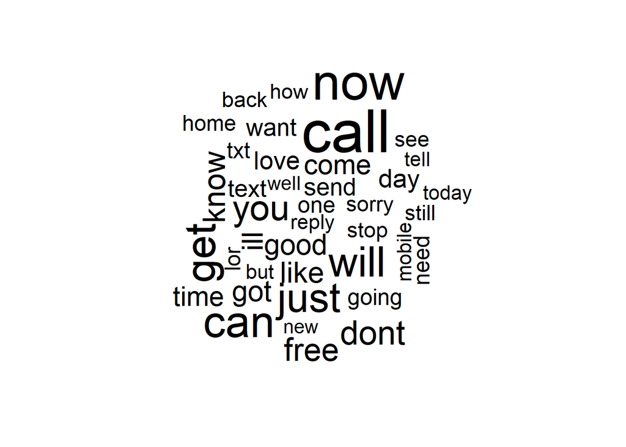

```r
wordcloud(smsRaw$text, max.words = 40)
```

```r
# build a corpus using the text mining (tm) package
library(tm)
library(SnowballC)
#volatile (in memory corpus from vector of text in R
smsC = VCorpus(VectorSource(smsRaw$text))
# clean up the corpus using tm_map()
smsCC = tm_map(smsC, content_transformer(tolower)) #upper -> lower
smsCC = tm_map(smsCC, removeNumbers) # remove numbers
smsCC = tm_map(smsCC, removeWords, stopwords()) # remove stop words
smsCC = tm_map(smsCC, removePunctuation) # remove punctuation
smsCC = tm_map(smsCC, stemDocument) #stemming
smsCC = tm_map(smsCC, stripWhitespace) # eliminate unneeded whitespace
```

## get document term matrix

```r
# create document term matrix
smsDtm <- DocumentTermMatrix(smsC, control = list(
tolower = TRUE,
removeNumbers = TRUE,
stopwords = TRUE,
removePunctuation = TRUE,
stemming = TRUE
))
dim(smsDtm)
```

```
## [1] 5559 6971
```

Out of sample misclassification

```r
# creating training and test datasets
smsTrain = smsDtm[1:4169, ]
smsTest = smsDtm[4170:5559, ]
smsTrainy = smsRaw[1:4169, ]$type
smsTesty = smsRaw[4170:5559, ]$type
cat("training fraction is: ",4169/5559,"\n")
```

```
## training fraction is:  0.749955
```

frequency words and convert counts to binary value

```r
smsFreqWords = findFreqTerms(smsTrain, 5)
#words that appear at leat 5 times
smsFreqTrain = smsTrain[ , smsFreqWords]
smsFreqTest = smsTest[ , smsFreqWords]
convertCounts <- function(x) {
x <- ifelse(x > 0, "Yes", "No")
}
# apply() convert_counts() to columns of train/test data
smsTrain = apply(smsFreqTrain, MARGIN = 2, convertCounts)
smsTest = apply(smsFreqTest, MARGIN = 2, convertCounts)

library(e1071)
smsNB = naiveBayes(smsTrain, smsTrainy, laplace=1)
yhat = predict(smsNB,smsTest)
ctab = table(yhat,smsTesty)
ctab
```

```
##       smsTesty
## yhat    ham spam
##   ham  1202   29
##   spam    5  154
```

```r
misclass = (sum(ctab)-sum(diag(ctab)))/sum(ctab)
perspam = ctab[2,2]/sum(ctab[,2])
cat("misclass,perspam: ", misclass,perspam,"\n")
```

```
## misclass,perspam:  0.02446043 0.8415301
```

Now we iterate through random train test split and change the laplace value and report confusion matrixs and misclassification rate for each combination

```r
# sample train/test
trainfrac=.75
n=length(smsRaw$type)
nTrain = floor(trainfrac*n)
result_missclassification <-matrix(, nrow=10,ncol=10)
result_perspam <-matrix(, nrow=10,ncol=10)
for(traintest in 1:10)
{
  for (laplace in 1:10)
{
set.seed(traintest)
ii = sample(1:n,nTrain)
smsTrain = smsDtm[ii, ]
smsTest = smsDtm[-ii, ]
smsTrainy = smsRaw[ii, ]$type
smsTesty = smsRaw[-ii, ]$type
# freq words
smsFreqWords = findFreqTerms(smsTrain, 5) #words that appear at leat 5 times
smsFreqTrain = smsTrain[ , smsFreqWords]
smsFreqTest = smsTest[ , smsFreqWords]
# counts -> binary
smsTrain = apply(smsFreqTrain, MARGIN = 2, convertCounts)
smsTest = apply(smsFreqTest, MARGIN = 2, convertCounts)
smsNB = naiveBayes(smsTrain, smsTrainy, laplace)
#pred and misclass
yhat = predict(smsNB,smsTest)
ctab = table(yhat,smsTesty)
cat("Confusion matrix and mis-classification for ", traintest," th split and laplace = ",laplace,"\n")
print(ctab)
missclass = (sum(ctab)-sum(diag(ctab)))/sum(ctab)
perspam = ctab[2,2]/sum(ctab[,2])
result_missclassification[traintest, laplace] = missclass
result_perspam[traintest, laplace] = perspam
cat("misclass,perspam: ", missclass,perspam,"\n")
}
}
```

```
## Confusion matrix and mis-classification for  1  th split and laplace =  1
##       smsTesty
## yhat    ham spam
##   ham  1213   22
##   spam    4  151
## misclass,perspam:  0.01870504 0.8728324
## Confusion matrix and mis-classification for  1  th split and laplace =  2
##       smsTesty
## yhat    ham spam
##   ham  1212   26
##   spam    5  147
## misclass,perspam:  0.02230216 0.849711
## Confusion matrix and mis-classification for  1  th split and laplace =  3
##       smsTesty
## yhat    ham spam
##   ham  1212   33
##   spam    5  140
## misclass,perspam:  0.02733813 0.8092486
## Confusion matrix and mis-classification for  1  th split and laplace =  4
##       smsTesty
## yhat    ham spam
##   ham  1212   41
##   spam    5  132
## misclass,perspam:  0.03309353 0.7630058
## Confusion matrix and mis-classification for  1  th split and laplace =  5
##       smsTesty
## yhat    ham spam
##   ham  1212   50
##   spam    5  123
## misclass,perspam:  0.03956835 0.7109827
## Confusion matrix and mis-classification for  1  th split and laplace =  6
##       smsTesty
## yhat    ham spam
##   ham  1212   60
##   spam    5  113
## misclass,perspam:  0.04676259 0.6531792
## Confusion matrix and mis-classification for  1  th split and laplace =  7
##       smsTesty
## yhat    ham spam
##   ham  1214   69
```

[output cut: 545 more lines]

```
##   ham  1192  106
##   spam    1   91
## misclass,perspam:  0.07697842 0.4619289
## Confusion matrix and mis-classification for  10  th split and laplace =  9
##       smsTesty
## yhat    ham spam
##   ham  1192  114
##   spam    1   83
## misclass,perspam:  0.08273381 0.4213198
## Confusion matrix and mis-classification for  10  th split and laplace =  10
##       smsTesty
## yhat    ham spam
##   ham  1192  125
##   spam    1   72
## misclass,perspam:  0.09064748 0.3654822
```

dataframe showing total missclassfication rate for combination of laplace and different splits

```r
print("total misclassification result for laplace-split combination")
```

```
## [1] "total misclassification result for laplace-split combination"
```

```r
result_missclassification<-data.frame(result_missclassification)
rownames(result_missclassification)<-c("split 1","split 2","split 3","split 4","split 5","split 6","split 7","split 8","split 9", "split10")
colnames(result_missclassification)<-c("laplace 1","laplace 2","laplace 3","laplace 4","laplace 5","laplace 6","laplace 7","laplace 8","laplace 9", "laplace 10")
print(result_missclassification)
```

```
##           laplace 1  laplace 2  laplace 3  laplace 4  laplace 5  laplace 6
## split 1 0.018705036 0.02230216 0.02733813 0.03309353 0.03956835 0.04676259
## split 2 0.024460432 0.02877698 0.03525180 0.04028777 0.04748201 0.05539568
## split 3 0.017985612 0.01942446 0.02446043 0.02733813 0.03237410 0.04028777
## split 4 0.016546763 0.01870504 0.02446043 0.02949640 0.03381295 0.04316547
## split 5 0.024460432 0.03021583 0.03525180 0.03956835 0.04244604 0.04676259
## split 6 0.009352518 0.01438849 0.02158273 0.02446043 0.03381295 0.04388489
## split 7 0.025179856 0.02733813 0.03237410 0.03453237 0.04028777 0.04532374
## split 8 0.022302158 0.02949640 0.03525180 0.04172662 0.04388489 0.05323741
## split 9 0.020143885 0.02446043 0.02805755 0.03381295 0.03741007 0.04244604
## split10 0.026618705 0.03021583 0.03453237 0.04100719 0.04964029 0.05395683
##          laplace 7  laplace 8  laplace 9 laplace 10
## split 1 0.05179856 0.05899281 0.06978417 0.07697842
## split 2 0.06834532 0.08129496 0.08705036 0.09856115
## split 3 0.04676259 0.05971223 0.06906475 0.07410072
## split 4 0.04820144 0.05827338 0.06187050 0.07194245
## split 5 0.05323741 0.06187050 0.06762590 0.07985612
## split 6 0.05251799 0.06546763 0.07625899 0.08633094
## split 7 0.05755396 0.06546763 0.06906475 0.07841727
## split 8 0.06043165 0.07194245 0.07841727 0.08705036
## split 9 0.05035971 0.05971223 0.06618705 0.07697842
## split10 0.06546763 0.07697842 0.08273381 0.09064748
```

plot and visulize the missclassification

```r
print("total perspam accuracy result for laplace-split combination")
```

```
## [1] "total perspam accuracy result for laplace-split combination"
```

```r
result_perspam<-data.frame(result_perspam)
rownames(result_perspam)<-c("split 1","split 2","split 3","split 4","split 5","split 6","split 7","split 8","split 9", "split10")
colnames(result_perspam)<-c("laplace 1","laplace 2","laplace 3","laplace 4","laplace 5","laplace 6","laplace 7","laplace 8","laplace 9", "laplace 10")
print(result_perspam)
```

```
##         laplace 1 laplace 2 laplace 3 laplace 4 laplace 5 laplace 6
## split 1 0.8728324 0.8497110 0.8092486 0.7630058 0.7109827 0.6531792
## split 2 0.8333333 0.8080808 0.7626263 0.7272727 0.6767677 0.6262626
## split 3 0.8720930 0.8546512 0.8313953 0.8023256 0.7616279 0.6976744
## split 4 0.8870056 0.8700565 0.8361582 0.7853107 0.7514124 0.6779661
## split 5 0.8287293 0.7955801 0.7569061 0.7292818 0.7016575 0.6574586
## split 6 0.9381443 0.9072165 0.8608247 0.8402062 0.7783505 0.7061856
## split 7 0.8315217 0.8097826 0.7771739 0.7663043 0.7228261 0.6739130
## split 8 0.8605769 0.8269231 0.7836538 0.7403846 0.7259615 0.6586538
## split 9 0.8546512 0.8197674 0.7906977 0.7441860 0.7151163 0.6686047
## split10 0.8274112 0.7969543 0.7715736 0.7258883 0.6649746 0.6243655
##         laplace 7 laplace 8 laplace 9 laplace 10
## split 1 0.6011561 0.5433526 0.4508671  0.3815029
## split 2 0.5353535 0.4444444 0.4040404  0.3232323
## split 3 0.6453488 0.5406977 0.4651163  0.4244186
## split 4 0.6384181 0.5593220 0.5310734  0.4519774
## split 5 0.6132597 0.5414365 0.4972376  0.3977901
## split 6 0.6391753 0.5463918 0.4690722  0.3917526
## split 7 0.5815217 0.5217391 0.4891304  0.4130435
## split 8 0.6105769 0.5336538 0.4855769  0.4278846
## split 9 0.5988372 0.5232558 0.4709302  0.3837209
## split10 0.5431472 0.4619289 0.4213198  0.3654822
```

```r
library(igraph)
library(randomcoloR)
randomColor(count = 1, hue = c(" ", "random", "red", "orange", "yellow",
"green", "blue", "purple", "pink", "monochrome"), luminosity = c(" ",
"random", "light", "bright", "dark"))
```

```
## [1] "#ff9328"
```

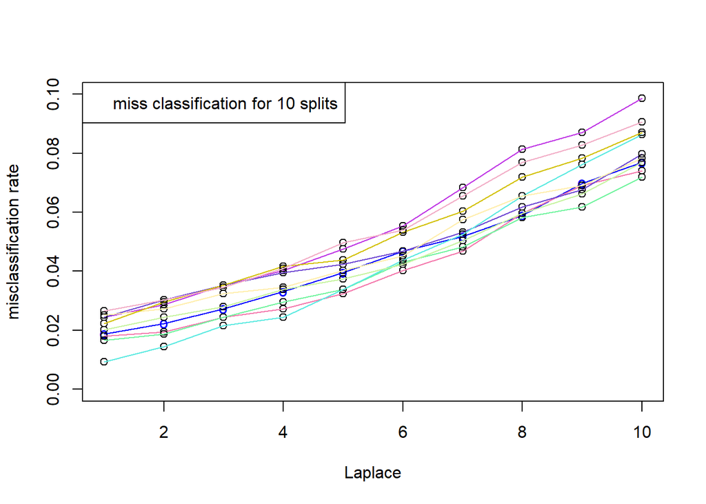

```r
x_laplace = c(1:10)
plot(x_laplace, result_missclassification[1,], xlab="Laplace",ylab="misclassification rate", type="o", col="blue", pch="o", lty=1, ylim=c(0,0.1))
legend("topleft", "miss classification for 10 splits")
for (i in 2:10){
  points(x_laplace,result_missclassification[i,],col="black")
  lines(x_laplace, result_missclassification[i,], col=randomColor())
}
```

```r
randomColor(count = 1, hue = c(" ", "random", "red", "orange", "yellow",
"green", "blue", "purple", "pink", "monochrome"), luminosity = c(" ",
"random", "light", "bright", "dark"))
```

```
## [1] "#90d4dd"
```

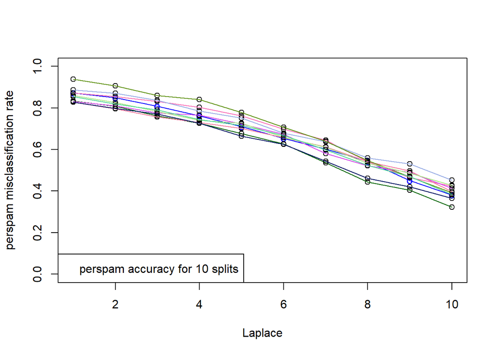

```r
x_laplace = c(1:10)
plot(x_laplace, result_perspam[1,], xlab="Laplace",ylab="perspam misclassification rate", type="o", col="blue", pch="o", lty=1, ylim=c(0,1))
legend("bottomleft", "perspam accuracy for 10 splits")
for (i in 2:10)
{
  points(x_laplace,result_perspam[i,],col="black")
  lines(x_laplace, result_perspam[i,], col=randomColor())
}
```

Observations 1. final classification results do fluctuate with different train/test split, which can cause around 0.02 deviation for total missclassification and around 0.1 deviation for perspam misclassification 2. with increase of laplace, total missclassification rate increases 3. with increase of laplace, perspam predicting accuracy decreases Hence when doing laplace smoothing, we should use a small laplace value to filter out the zero conditional probability for unseen data while increasing the smoothing will make the classifier perform worse.